# Regression modelling

statistics

regression

insurance

This article sets out a few practical recipes for modelling with (life) insurance data. Insurance events are typically of low probability - these recipes consider some of the limitations of “small data” model fitting (where the observations of interest are sparse) and other topics for insurance like comparisons to standard tables.

Pat Reen https://www.linkedin.com/in/patrick-reen/  
2021-10-14

# Overview

## Background

Here I’ve pulled together a few simple regression tools using (life) insurance data. See earlier article on data transformations/ preparation. Insurance events are typically of low probability - these recipes consider some of the limitations of “small data” model fitting (where the observations of interest are sparse) and other topics for insurance like comparisons to standard tables. Themes covered:

- Regression
  - Grouped vs ungrouped data
  - Choice of: response distribution, link (and offsets), explanatory variables
  - Modelling variance to industry/ reference (A/E or A - E)
  - Model selection: stepwise regression, likelihood tests, model evaluation
  - Predictions, confidence intervals and visualisations

See link above to GitHub repository which has the detailed code.

## Libraries

A list of packages used in the recipes.

```r
library(rmdformats) # theme for the HTML doc
library(bookdown)   # bibliography formatting
library(kableExtra) # formatting tables
library(scales)     # data formatting
library(dplyr)      # tidyverse: data manipulation
library(tidyr)      # tidyverse: tidy messy data
library(corrplot)   # correlation matrix visualisation, optional
library(ggplot2)    # tidyverse: graphs
library(pdp)        # tidyverse: arranging plots
library(GGally)     # tidyverse: extension of ggplot2
library(ggthemes)   # tidyverse: additional themes for ggplot, optional
library(plotly)     # graphs, including 3D
library(caret)      # sampling techniques
library(broom)      # tidyverse: visualising statistical objects
library(pROC)       # visualising ROC curves
library(lmtest)     # tests for regression models

# packages below have some interaction with earlier packages, not always needed
library(arm)        # binned residual plot
library(msme)       # statistical tests, pearson dispersion
library(MASS)       # statistics
```

## Further reading

A few books and articles of interest:

- [R Markdown Cookbook](https://bookdown.org/yihui/rmarkdown-cookbook/) has everything you need to know to set up an r markdown document like this one.
- [Generalised Linear Models for Insurance Data](https://www.cambridge.org/au/academic/subjects/statistics-probability/statistics-econometrics-finance-and-insurance/generalized-linear-models-insurance-data?format=HB&isbn=9780521879149) is a great book introducing GLMs in the context of insurance, considering problems specific to insurance data.
- [Tidyverse documentation](https://www.tidyverse.org/) full set of documentation for Tidyverse packages (packages for data science) e.g. dplyr for data manipulation; tidyr for tidying up messy data; ggplot for visualisation.

# Model selection

The sections below provide a refresher on linear and logistic regression; some considerations for insurance data; model selection and testing model fit.

## Splitting data

### Training vs testing data

Split data into training and testing data sets. We will used 75% of the data for training and the rest for testing.

```r
# Determine the number of rows for training
nrow(df)
```

```
[1] 600000
```

```r
# Create a random sample of row IDs
sample_rows <- sample(nrow(df),0.75*nrow(df))
# Create the training dataset
df_train <- df[sample_rows,]
# Create the test dataset
df_test <- df[-sample_rows,]
```

### Class imbalance

Looking at the random sample we have created, we have a significant imbalance between successes and failures.

```r
df_train %>% select(inc_count_acc,inc_count_sick) %>% table()
```

```
             inc_count_sick
inc_count_acc      0      1
            0 447547   1574
            1    879      0
```

Generally, “in insurance applications, the prediction of a claim or no claim on an individual policy is rarely the point of statistical modelling … The model is useful provided it explains the variability in claims behaviour, as a function of risk factors.” (Piet de Jong, Gillian Z. Heller 2008, p108–109) So, as long as we have sufficient actual claims to justify the level of predictor variables fitted to the model we should be ok.

However, in some cases where it is important to correctly predict the binary categorical response variable, we may need to create a sample that has a roughly equal proportion of classes (of successes and failures) and then fit our model to that data. E.g. where we are looking to accurately predict fraud within banking transactions data.

To do that we need to refine our sampling method

- Down sampling: the majority class is randomly down sampled to be of the same size as the smaller class.
- Up sampling: rows from the minority class (e.g. claim) are repeatedly sampled over and over until they reaches the same size as the majority class (not claim).
- Hybrid sampling: artificial data points are generated and are systematically added around the minority class.

Showing a method for down sampling below - this is more useful for pure classification models; not that useful for insurance applications.

```r
# Determine the number of rows for training
df_train_ds <- downSample(df_train,factor(df_train$inc_count_sick))
df_train_ds %>% select(inc_count_sick) %>% table()
```

```
.
   0    1
1574 1574
```

## Regression

### Background

Linear regression is a method of modelling the relationship between a response (dependent variable) and one or more explanatory variables (predictors; independent variables). For a data set , the relationship between y, the response/ dependent variables and the vector of x’s, the explanatory variables, is linear of the form

$y_{i} = \beta_{0} + \beta_{1}x_{i1} + ... + \beta_{p}x_{ip} + \epsilon_{i} = \mathbf{x}_{i}^t\mathbf{\beta} + \epsilon_{i}$, $i = 1,...,n$

Key assumptions

- linearity - response is some linear combination of regression coefficients and explanatory variables
- constant variance (homoskedastic) - variance of errors does not depend upon explanatory variables
- errors are independent - response variables uncorrelated
- explanatory variables are not perfectly co-linear
- weak exogeneity - predictors treated as fixed / no measurement error.

### Linear vs logistic regression

- Linear: Continuous response outcome i.e. predicting a continuous response/dependent variable using a set of explanatory variables
- Logistic: Binary response outcome - straight line does not fit the data well. The predicted values are always between 0 and 1.

For logistic regression the log odds are linear. We can transform to odds ratios by taking the exponential of the coefficients or exp(coef(model)) - this shows the relative change to odds of the response variables, where

- Odds-ratio = 1, the coefficient has no effect.
- Odds-ratio is <1, the coefficient predicts a decreased chance of an event occurring.
- Odds-ratio is >1, the coefficient predicts an increased chance of an event occurring.

### Logistic regression for claims incidence

A simple regression model is shown below. Interpreting co-efficients and other output:

- Intercept - global intercept and reference intercepts for each group (reference intercept: + contract (y~x); or intercept for each group: y~x-1)
- Slopes - other coefficients, estimates linear coefficient for continuous variable

Other output

- Pr(>|z|)/ p value is the probability coefficient result you’re seeing happened due to random variation. Commonly a p-value of .05 or less is significant.
- AIC and likelihood tests, useful for model comparison.
- Residuals sections gives summary stats of the model.
- Call gives the form of the model.
- vcov(model) gives the variance-covariance matrix for fitted model (diagonals are variance and off diagonals are covariance - 0 if all variables are orthogonal).
- coef(model) returns the model coefficients.

```r
model_1 <- glm(inc_count_sick~age,data=df_train,family="binomial") # use the default link
summary(model_1)
```

```
Call:
glm(formula = inc_count_sick ~ age, family = "binomial", data = df_train)

Deviance Residuals:
    Min       1Q   Median       3Q      Max
-0.1719  -0.0925  -0.0764  -0.0662   3.8636

Coefficients:
              Estimate Std. Error z value Pr(>|z|)
(Intercept) -10.143801   0.221246  -45.85   <2e-16 ***
age           0.095743   0.004542   21.08   <2e-16 ***
---
Signif. codes:  0 '***' 0.001 '**' 0.01 '*' 0.05 '.' 0.1 ' ' 1

(Dispersion parameter for binomial family taken to be 1)

    Null deviance: 20946  on 449999  degrees of freedom
Residual deviance: 20499  on 449998  degrees of freedom
AIC: 20503

Number of Fisher Scoring iterations: 9
```

Choice of [link function](https://en.wikipedia.org/wiki/Generalized_linear_model): the link function defines the relationship of response variables to mean. It is usually sufficient to use the standard link. Section below shows a model with the link specified (results are the same as the model above).

```r
model_2 <- glm(inc_count_sick~age,data=df_train,family=binomial(link="logit")) # specify the link, logit is default for binomial
summary(model_2)
```

[output not shown]

Adding more response variables: When deciding on explanatory variables to model, consider the properties of the data (like correlation or colinearity).

```r
model_3 <- glm(inc_count_sick~age+policy_year+sex+waiting_period,data=df_train,family=binomial(link="logit"))
summary(model_3)
```

```
Call:
glm(formula = inc_count_sick ~ age + policy_year + sex + waiting_period,
    family = binomial(link = "logit"), data = df_train)

Deviance Residuals:
    Min       1Q   Median       3Q      Max
-0.2363  -0.0979  -0.0751  -0.0522   4.0480

Coefficients:
                    Estimate Std. Error z value Pr(>|z|)
(Intercept)        -9.507516   0.247391 -38.431  < 2e-16 ***
age                 0.092744   0.005108  18.155  < 2e-16 ***
policy_year         0.012077   0.010813   1.117  0.26402
sexf               -0.723963   0.080513  -8.992  < 2e-16 ***
sexu               -0.392234   0.133309  -2.942  0.00326 **
waiting_period14d  -0.225423   0.107046  -2.106  0.03522 *
waiting_period720d -1.831494   0.184362  -9.934  < 2e-16 ***
waiting_period90d  -1.590302   0.155151 -10.250  < 2e-16 ***
---
Signif. codes:  0 '***' 0.001 '**' 0.01 '*' 0.05 '.' 0.1 ' ' 1

(Dispersion parameter for binomial family taken to be 1)

    Null deviance: 20946  on 449999  degrees of freedom
Residual deviance: 20032  on 449992  degrees of freedom
AIC: 20048

Number of Fisher Scoring iterations: 9
```

### Linear regression for claims incidence

Choice of response distribution: In the logistic regression example above we considered the Binomial response distribution. Other common count distributions are

- [Poisson](https://en.wikipedia.org/wiki/Poisson_distribution) distribution: mean and variance are equal.

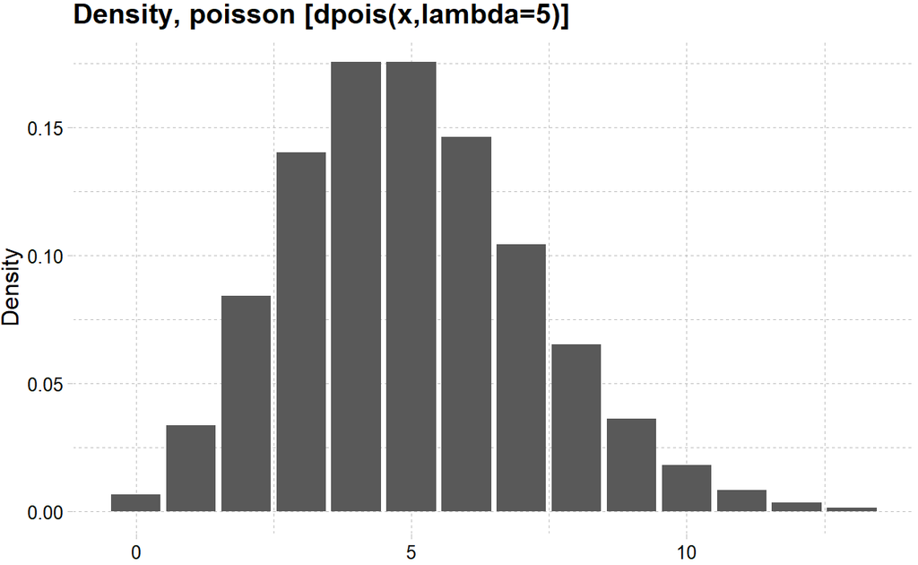

```r
lower<-qpois(0.001, lambda=5)
upper<-qpois(0.999, lambda=5)
x<-seq(lower,upper,1)

data.frame(x, y=dpois(x, lambda=5)) %>% ggplot(mapping=aes(y=y,x=x)) + geom_col()+
labs(x=NULL, y="Density", title = "Density, poisson [dpois(x,lambda=5)]")+
theme_pander() + scale_color_gdocs()
```

- [Negative Binomial](https://en.wikipedia.org/wiki/Negative_binomial_distribution) distribution: can handle Poission overdispersion (where the variance is bigger than expected).

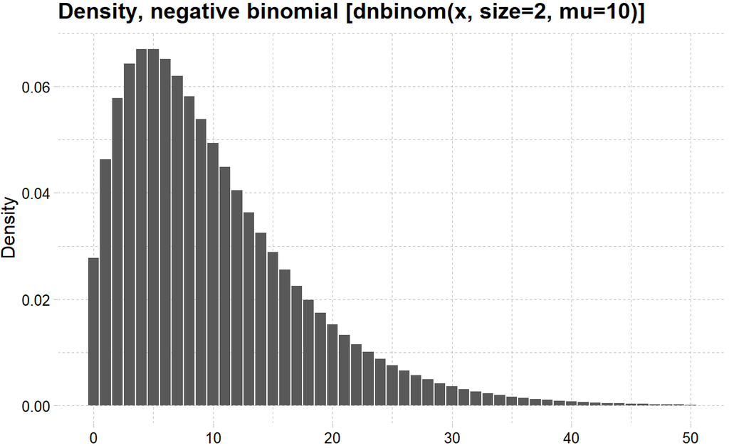

```r
lower<-qnbinom(0.001, size=2, mu=10)
upper<-qnbinom(0.999, size=2, mu=10)
x<-seq(lower,upper,1)

data.frame(x, y=dnbinom(x, size=2, mu=10)) %>% ggplot(mapping=aes(y=y,x=x)) + geom_col()+
labs(x=NULL, y="Density", title = "Density, negative binomial [dnbinom(x, size=2, mu=10)]")+
theme_pander() + scale_color_gdocs()
```

And amount

- [Normal](https://en.wikipedia.org/wiki/Normal_distribution) distribution

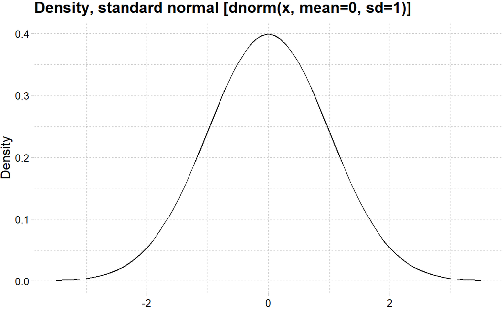

```r
x<-seq(-3.5,3.5,0.1)
data.frame(x,y=dnorm(x, mean=0, sd=1)) %>% ggplot(mapping=aes(y=y,x=x)) + geom_line()+
labs(x=NULL, y="Density", title = "Density, standard normal [dnorm(x, mean=0, sd=1)]")+
theme_pander() + scale_color_gdocs()
```

- [Gamma](https://stat.ethz.ch/R-manual/R-devel/library/stats/html/GammaDist.html) distribution: allows for a fatter tail.

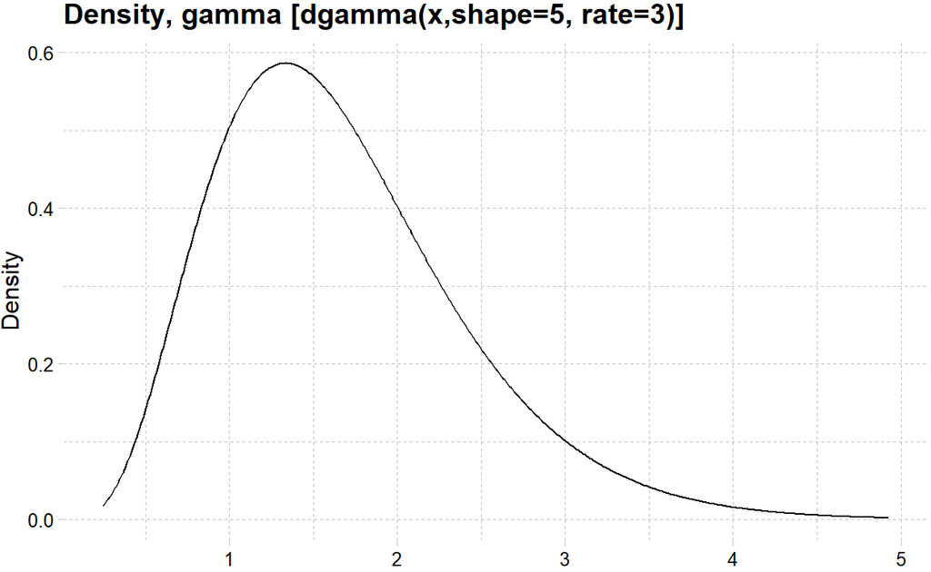

```r
lower<-qgamma(0.001, shape=5, rate=3)
upper<-qgamma(0.999, shape=5, rate=3)
x<-seq(lower,upper,0.01)

data.frame(x,y=dgamma(x, shape=5, rate=3)) %>% ggplot(mapping=aes(y=y,x=x)) + geom_line()+
labs(x=NULL, y="Density", title = "Density, gamma [dgamma(x,shape=5, rate=3)]")+
theme_pander() + scale_color_gdocs()
```

An example of an amount model, assuming a normal response distribution

```r
amount_model_3 <- glm(inc_amount_sick~age+sex+waiting_period,data=df_train)
tidy(amount_model_3)
```

```
# A tibble: 7 x 5
  term               estimate std.error statistic   p.value
  <chr>                 <dbl>     <dbl>     <dbl>     <dbl>
1 (Intercept)          -95.8      6.89     -13.9  5.59e- 44
2 age                    3.08     0.129     24.0  1.05e-126
3 sexf                 -17.2      1.80      -9.56 1.24e- 21
4 sexu                 -10.7      3.34      -3.19 1.41e-  3
5 waiting_period14d     -6.54     3.74      -1.75 8.01e-  2
6 waiting_period720d   -33.8      4.23      -7.98 1.51e- 15
7 waiting_period90d    -31.7      4.08      -7.77 7.80e- 15
```

## (Un)grouped data

The models above were based upon ungrouped data, but earlier we noted that data are often grouped. In grouping data, some detail is usually lost e.g. we no longer have any true continuous categorical response variables. In this case, the columns relating to actual events (here claims) are a sum of the individual instance; more at Piet de Jong, Gillian Z. Heller (2008), p49, 105.

The example below compares a model of counts by age and sex on the grouped and shows that the derived parameters are materially similar.

```r
# grouped model
model_4 <- glm(cbind(inc_count_sick,exposure-inc_count_sick)~age+sex,data=df_grp,family=binomial(link="logit")) # cbind gives a matrix of successes and failures
```

Use tidy to visualise the modelled result for grouped data:

```r
tidy(model_4)
```

```
# A tibble: 4 x 5
  term        estimate std.error statistic   p.value
  <chr>          <dbl>     <dbl>     <dbl>     <dbl>
1 (Intercept)  -9.83     0.192      -51.3  0
2 age           0.0918   0.00394     23.3  4.41e-120
3 sexf         -0.741    0.0703     -10.5  5.56e- 26
4 sexu         -0.461    0.119       -3.88 1.04e-  4
```

Modelling using ungrouped data, coefficients materially similar

```r
model_5 <- glm(inc_count_sick~age+sex,data=df,family=binomial(link="logit"))
```

Use tidy to visualise the modelled result for ungrouped data:

```r
tidy(model_5)
```

```
# A tibble: 4 x 5
  term        estimate std.error statistic   p.value
  <chr>          <dbl>     <dbl>     <dbl>     <dbl>
1 (Intercept)  -9.83     0.192      -51.3  0
2 age           0.0918   0.00394     23.3  4.42e-120
3 sexf         -0.741    0.0703     -10.5  5.57e- 26
4 sexu         -0.461    0.119       -3.88 1.04e-  4
```

### Offsets

When the data are grouped, it is important to consider the level of exposure in a given group. This can be achieved with an [offset](https://towardsdatascience.com/offsetting-the-model-logic-to-implementation-7e333bc25798) term (Piet de Jong, Gillian Z. Heller (2008), p66-67). This is important in an insurance context where we are often interested in modelling rates of claim.

```r
df_grp_filtered <- df_grp %>% filter(inc_count_tot>1, exposure>10)
model_6 <- glm(inc_amount_tot~age+sex+offset(sum_assured),data=df_grp_filtered)
tidy(model_6)
```

```
# A tibble: 4 x 5
  term         estimate std.error statistic  p.value
  <chr>           <dbl>     <dbl>     <dbl>    <dbl>
1 (Intercept) -3454137.   526285.     -6.56 2.39e-10
2 age            50880.    10976.      4.64 5.37e- 6
3 sexf          808044.   134595.      6.00 5.70e- 9
4 sexu         1087955.   542771.      2.00 4.59e- 2
```

```r
model_7 <- glm(inc_amount_tot~age+sex,data=df_grp_filtered)
tidy(model_7)
```

```
# A tibble: 4 x 5
  term        estimate std.error statistic p.value
  <chr>          <dbl>     <dbl>     <dbl>   <dbl>
1 (Intercept)    8153.     5657.     1.44   0.151
2 age             204.      118.     1.73   0.0842
3 sexf          -3454.     1447.    -2.39   0.0176
4 sexu          -3801.     5834.    -0.652  0.515
```

## Actuals or AvE?

The models we have fitted above are based upon actual claim incidences. We can consider the difference between some expected claim rate (e.g. from a standard table) and the actuals.

Using the grouped data again, we model A/E with a normal response distribution. The model shows that none of the coeffients are significant indicating no material difference to expected, which is consistent with the data as the observations were derived from the expected probabilities initially.

```r
# grouped model
model_8 <- glm(inc_count_sick/inc_count_sick_exp~age+sex,data=df_grp)
# use tidy to visualise the modelled result
summary(model_8)
```

```
Call:
glm(formula = inc_count_sick/inc_count_sick_exp ~ age + sex,
    data = df_grp)

Deviance Residuals:
    Min       1Q   Median       3Q      Max
  -1.19    -0.97    -0.93    -0.87  2571.52

Coefficients:
             Estimate Std. Error t value Pr(>|t|)
(Intercept)  0.725747   0.456016   1.591    0.112
age          0.004747   0.009713   0.489    0.625
sexf        -0.091246   0.154067  -0.592    0.554
sexu         0.174939   0.208211   0.840    0.401

(Dispersion parameter for gaussian family taken to be 514.2801)

    Null deviance: 56358742  on 109589  degrees of freedom
Residual deviance: 56357894  on 109586  degrees of freedom
AIC: 995154

Number of Fisher Scoring iterations: 2
```

## Stepwise regression

This method builds a regression model from a set of candidate predictor variables by entering predictors based on p values, in a stepwise manner until there are no variables left to enter any more. Model may over/ understate the importance of predictors and the direction of stepping (forward or backward) can impact the outcome - so some degree of interpretation is necessary.

```r
# specify a null model with no predictors
null_model_sick <- glm(inc_count_sick ~ 1, data = df_train, family = "binomial")

# specify the full model using all of the potential predictors
full_model_sick <- glm(inc_count_sick ~ cal_year + policy_year + sex + smoker + benefit_period + waiting_period + occupation + poly(age,3) + sum_assured + policy_year*age + policy_year*sum_assured, data = df_train, family = "binomial")

# alternatively, glm(y~ . -x1) fits model using all variables excluding x1

# use a forward stepwise algorithm to build a parsimonious model
step_model_sick <- step(null_model_sick, scope = list(lower = null_model_sick, upper = full_model_sick), direction = "forward")
```

```
Start:  AIC=20948.4
inc_count_sick ~ 1

                 Df Deviance   AIC
+ age             1    20499 20503
+ poly(age, 3)    3    20497 20505
+ waiting_period  3    20581 20589
+ policy_year     1    20833 20837
+ sum_assured     1    20842 20846
+ sex             2    20844 20850
+ smoker          2    20925 20931
+ cal_year        1    20932 20936
<none>                 20946 20948
+ benefit_period  2    20945 20951
+ occupation      4    20941 20951

Step:  AIC=20503.31
inc_count_sick ~ age

                 Df Deviance   AIC
+ waiting_period  3    20135 20145
+ sex             2    20398 20406
+ smoker          2    20478 20486
+ sum_assured     1    20482 20488
<none>                 20499 20503
+ policy_year     1    20498 20504
+ cal_year        1    20499 20505
+ poly(age, 3)    2    20497 20505
+ occupation      4    20494 20506
+ benefit_period  2    20498 20506

Step:  AIC=20145.08
inc_count_sick ~ age + waiting_period

                 Df Deviance   AIC
+ sex             2    20033 20047
+ smoker          2    20114 20128
+ sum_assured     1    20118 20130
<none>                 20135 20145
+ policy_year     1    20134 20146
```

[output cut: 25 more lines]

```
+ poly(age, 3)    2    20009 20031
+ cal_year        1    20012 20032
+ occupation      4    20006 20032
+ benefit_period  2    20011 20033

Step:  AIC=20015.39
inc_count_sick ~ age + waiting_period + sex + smoker + sum_assured

                 Df Deviance   AIC
<none>                 19995 20015
+ policy_year     1    19994 20016
+ poly(age, 3)    2    19993 20017
+ cal_year        1    19995 20017
+ benefit_period  2    19994 20018
+ occupation      4    19995 20023
```

```r
summary(full_model_sick)
```

```
Call:
glm(formula = inc_count_sick ~ cal_year + policy_year + sex +
    smoker + benefit_period + waiting_period + occupation + poly(age,
    3) + sum_assured + policy_year * age + policy_year * sum_assured,
    family = "binomial", data = df_train)

Deviance Residuals:
    Min       1Q   Median       3Q      Max
-0.2568  -0.0983  -0.0740  -0.0512   4.0416

Coefficients: (1 not defined because of singularities)
                          Estimate Std. Error z value Pr(>|z|)
(Intercept)             -4.710e+01  6.626e+01  -0.711  0.47714
cal_year                 2.058e-02  3.283e-02   0.627  0.53070
policy_year             -1.077e-01  1.018e-01  -1.058  0.28991
sexf                    -7.244e-01  8.052e-02  -8.997  < 2e-16 ***
sexu                    -3.912e-01  1.333e-01  -2.934  0.00334 **
smokers                  3.464e-01  7.424e-02   4.666 3.07e-06 ***
smokeru                 -1.076e-01  1.239e-01  -0.869  0.38493
benefit_period2yr       -9.245e-02  8.108e-02  -1.140  0.25414
benefit_period5yr       -3.854e-02  7.952e-02  -0.485  0.62796
waiting_period14d       -2.306e-01  1.071e-01  -2.154  0.03121 *
waiting_period720d      -1.837e+00  1.844e-01  -9.964  < 2e-16 ***
waiting_period90d       -1.595e+00  1.552e-01 -10.281  < 2e-16 ***
occupationsed           -2.305e-02  9.765e-02  -0.236  0.81336
occupationtechn         -5.071e-02  1.022e-01  -0.496  0.61970
occupationwhite         -6.020e-02  1.013e-01  -0.594  0.55238
occupationblue          -3.262e-02  1.189e-01  -0.274  0.78383
poly(age, 3)1            3.006e+02  4.680e+01   6.423 1.34e-10 ***
poly(age, 3)2           -4.075e+01  2.723e+01  -1.497  0.13445
poly(age, 3)3           -7.897e+00  2.002e+01  -0.394  0.69328
sum_assured              4.281e-05  2.744e-05   1.560  0.11867
age                             NA         NA      NA       NA
policy_year:age          2.424e-03  2.110e-03   1.149  0.25072
policy_year:sum_assured -4.251e-08  3.969e-06  -0.011  0.99145
---
Signif. codes:  0 '***' 0.001 '**' 0.01 '*' 0.05 '.' 0.1 ' ' 1

(Dispersion parameter for binomial family taken to be 1)

    Null deviance: 20946  on 449999  degrees of freedom
Residual deviance: 19987  on 449978  degrees of freedom
AIC: 20031

Number of Fisher Scoring iterations: 9
```

```r
summary(step_model_sick)
```

```
Call:
glm(formula = inc_count_sick ~ age + waiting_period + sex + smoker +
    sum_assured, family = "binomial", data = df_train)

Deviance Residuals:
    Min       1Q   Median       3Q      Max
-0.2830  -0.0973  -0.0745  -0.0519   4.0246

Coefficients:
                     Estimate Std. Error z value Pr(>|z|)
(Intercept)        -9.640e+00  2.432e-01 -39.635  < 2e-16 ***
age                 8.953e-02  4.755e-03  18.829  < 2e-16 ***
waiting_period14d  -2.295e-01  1.071e-01  -2.144  0.03202 *
waiting_period720d -1.835e+00  1.844e-01  -9.951  < 2e-16 ***
waiting_period90d  -1.594e+00  1.552e-01 -10.273  < 2e-16 ***
sexf               -7.238e-01  8.052e-02  -8.989  < 2e-16 ***
sexu               -3.916e-01  1.333e-01  -2.937  0.00331 **
smokers             3.466e-01  7.424e-02   4.669 3.03e-06 ***
smokeru            -1.067e-01  1.239e-01  -0.862  0.38885
sum_assured         4.333e-05  1.064e-05   4.072 4.66e-05 ***
---
Signif. codes:  0 '***' 0.001 '**' 0.01 '*' 0.05 '.' 0.1 ' ' 1

(Dispersion parameter for binomial family taken to be 1)

    Null deviance: 20946  on 449999  degrees of freedom
Residual deviance: 19995  on 449990  degrees of freedom
AIC: 20015

Number of Fisher Scoring iterations: 9
```

## Confidence intervals

We can compute the confidence intervals for one or more parameters in a fitted model.

```r
confint(step_model_sick) # add second argument specifying which parameters we need a confint for
```

```
                           2.5 %        97.5 %
(Intercept)        -1.011939e+01 -9.1658786725
age                 8.021044e-02  0.0988490230
waiting_period14d  -4.333078e-01 -0.0131725684
waiting_period720d -2.205152e+00 -1.4802247926
waiting_period90d  -1.900406e+00 -1.2909882621
sexf               -8.848852e-01 -0.5690645113
sexu               -6.636738e-01 -0.1401306177
smokers             1.985219e-01  0.4896777597
smokeru            -3.586694e-01  0.1276681057
sum_assured         2.248727e-05  0.0000642007
```

## Predictions

predict() is a generic function that can be used to predict results from various model forms. The function takes the form below. For logistic regression, setting prediction type to response produces a probability rather than log odds (which are difficult to interpret).

```r
# predictions
pred_inc_count_sick <- as.data.frame(
  predict(step_model_sick, data= df_train, # model and data
  type="response", # or terms for coefficients
  se.fit = TRUE, # default is false
  interval = "confidence", #default "none", also "prediction"
  level = 0.95
  # ...
  )
)

# add back to data
ifrm("df_train_pred")
pred_inc_count_sick <- rename(pred_inc_count_sick,pred_rate_inc_count_sick=fit,se_rate_inc_count_sick=se.fit)
df_train_pred <- cbind(df_train,pred_inc_count_sick)
```

We can plot the results by age and sex against the crude rates from earlier:

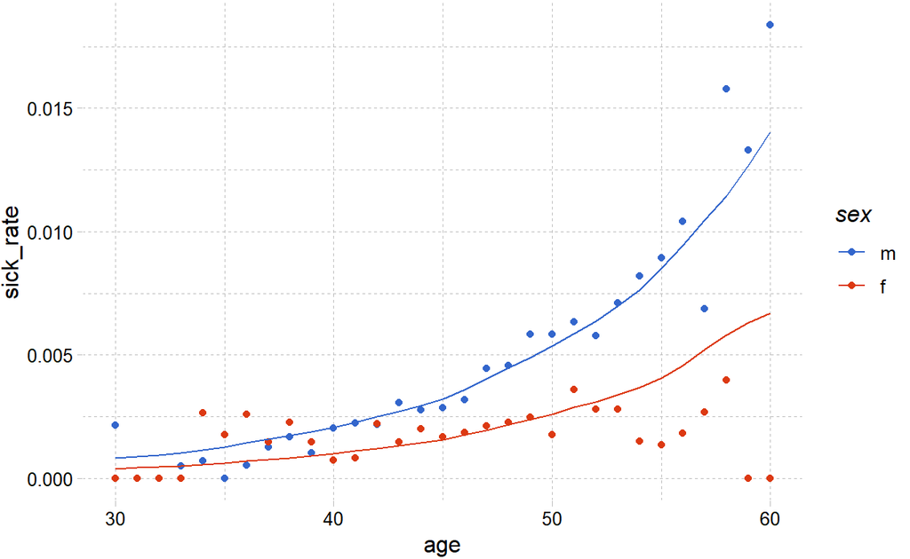

```r
# from earlier, summarise data by age and sex
df_train_pred %>% filter(sex != "u", between(age, 30,60)) %>% group_by(age,sex) %>%
summarise(total_sick=sum(inc_count_sick),total_acc=sum(inc_count_acc), pred_total_sick=sum(pred_rate_inc_count_sick),exposure=n(),.groups = 'drop') %>%
mutate(sick_rate = total_sick/exposure,pred_sick_rate = pred_total_sick/exposure, acc_rate = total_acc/exposure) %>%
# used ggplot to graph the results
ggplot(aes(x=age,y=sick_rate,color=sex)) +
# ylim(0,1) +
geom_point() +
# add a modeled line
geom_line(aes(x=age,y=pred_sick_rate)) +
theme_pander() + scale_color_gdocs()
```